# Credit Card Fraud Detection

Jaeseung Lee (jsl8@illinois.edu)

Nov 19th 2020

## Abstract

As the dataset is highly imbalanced, we need to implement oversampling and undersampling on target condition wheter credit card transaction is fraud or geniune. Therefore, we focused on applying SMOTE method and compare performances of several models based on “Sensitivity” and “F1 Score”, not the accuracy. And we will evaluate the performace after using SMOTE.

## Introduction

Today, most people save credit cards in smart phone application such as samsung pay, apple pay, paypal and etc. Additionally, people save credit card’s information for convenience when they shopping online in Amazon or Ebay. There are a high possibility that card information will be stolen when they visit ads which have virus that extract information in mobile or computer. To prevent this risk, the credit card company wants to develop a ML model that identify credit cards transactions whether credit card use is fraud or geniune.

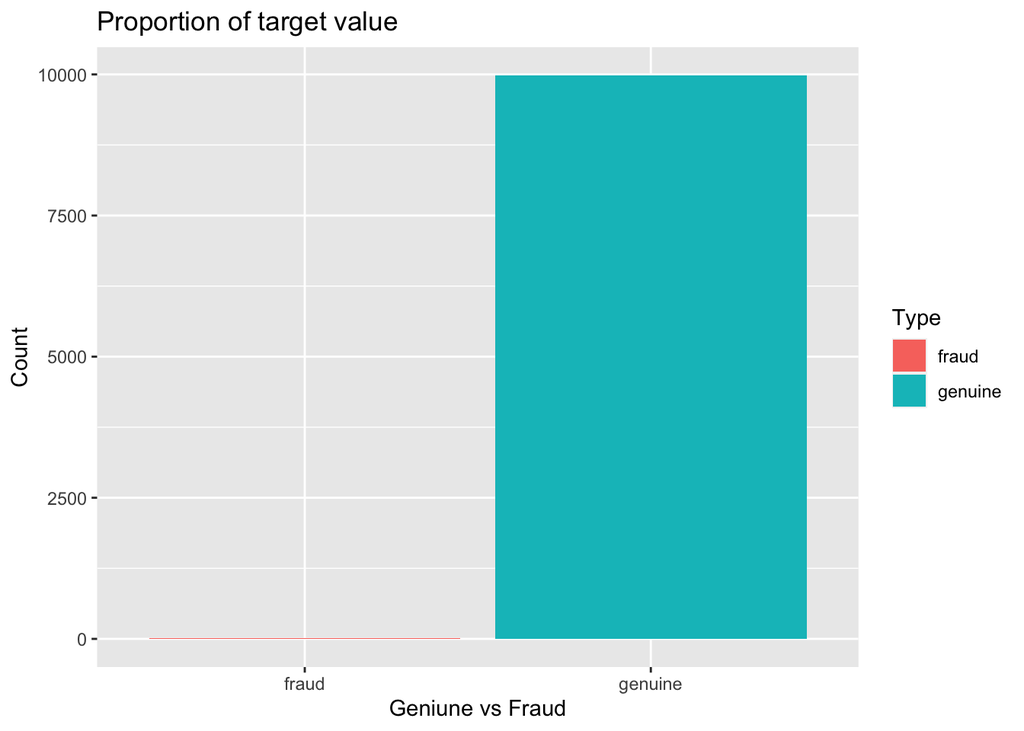

```
##
##   fraud genuine
##  0.0015  0.9985
```

## Methods

### 1. Train-Test Split

### 2. Preprocessing

Data summary

| Name | cc_sub_trn |
| --- | --- |
| Number of rows | 8000 |
| Number of columns | 31 |
| _______________________ |  |
| Column type frequency: |  |
| factor | 1 |
| numeric | 30 |
| ________________________ |  |
| Group variables | None |

**Variable type: factor**

| skim_variable | n_missing | complete_rate | ordered | n_unique | top_counts |
| --- | --- | --- | --- | --- | --- |
| Class | 0 | 1 | FALSE | 2 | gen: 7988, fra: 12 |

**Variable type: numeric**

| skim_variable | n_missing | complete_rate | mean | sd | p0 | p25 | p50 | p75 | p100 | hist |
| --- | --- | --- | --- | --- | --- | --- | --- | --- | --- | --- |
| Time | 0 | 1 | 94061.61 | 47332.47 | 0.00 | 53625.50 | 83004.50 | 138706.25 | 172774.00 | ▃▇▅▆▇ |
| V1 | 0 | 1 | -0.07 | 2.03 | -40.04 | -0.95 | -0.07 | 1.28 | 2.45 | ▁▁▁▁▇ |
| V2 | 0 | 1 | -0.02 | 1.70 | -38.43 | -0.61 | 0.08 | 0.80 | 12.35 | ▁▁▁▇▁ |
| V3 | 0 | 1 | 0.03 | 1.54 | -24.67 | -0.81 | 0.22 | 1.05 | 3.86 | ▁▁▁▁▇ |
| V4 | 0 | 1 | 0.00 | 1.45 | -4.79 | -0.86 | -0.03 | 0.76 | 11.79 | ▂▇▁▁▁ |
| V5 | 0 | 1 | -0.02 | 1.45 | -31.36 | -0.72 | -0.06 | 0.63 | 20.90 | ▁▁▇▇▁ |
| V6 | 0 | 1 | 0.02 | 1.34 | -11.50 | -0.75 | -0.25 | 0.41 | 21.19 | ▁▇▁▁▁ |
| V7 | 0 | 1 | 0.02 | 1.28 | -23.93 | -0.56 | 0.04 | 0.58 | 29.21 | ▁▁▇▁▁ |
| V8 | 0 | 1 | 0.03 | 1.03 | -23.12 | -0.21 | 0.03 | 0.34 | 11.58 | ▁▁▁▇▁ |
| V9 | 0 | 1 | 0.00 | 1.13 | -8.60 | -0.64 | -0.06 | 0.61 | 9.10 | ▁▁▇▁▁ |
| V10 | 0 | 1 | 0.01 | 1.14 | -15.23 | -0.54 | -0.11 | 0.47 | 13.25 | ▁▁▇▁▁ |
| V11 | 0 | 1 | 0.03 | 1.02 | -4.34 | -0.73 | -0.01 | 0.77 | 9.32 | ▁▇▂▁▁ |
| V12 | 0 | 1 | 0.02 | 0.97 | -13.38 | -0.38 | 0.16 | 0.63 | 3.36 | ▁▁▁▆▇ |
| V13 | 0 | 1 | 0.00 | 0.99 | -3.88 | -0.65 | -0.01 | 0.65 | 3.95 | ▁▃▇▂▁ |
| V14 | 0 | 1 | -0.01 | 0.95 | -12.78 | -0.44 | 0.05 | 0.49 | 6.24 | ▁▁▁▇▁ |
| V15 | 0 | 1 | 0.00 | 0.93 | -3.49 | -0.61 | 0.04 | 0.65 | 5.13 | ▁▆▇▁▁ |
| V16 | 0 | 1 | 0.00 | 0.87 | -10.62 | -0.46 | 0.07 | 0.51 | 6.00 | ▁▁▂▇▁ |
| V17 | 0 | 1 | -0.01 | 0.85 | -21.02 | -0.49 | -0.07 | 0.38 | 6.74 | ▁▁▁▇▁ |
| V18 | 0 | 1 | -0.01 | 0.84 | -8.40 | -0.49 | 0.00 | 0.50 | 4.08 | ▁▁▁▇▁ |
| V19 | 0 | 1 | -0.01 | 0.82 | -3.72 | -0.47 | 0.00 | 0.47 | 4.14 | ▁▂▇▁▁ |
| V20 | 0 | 1 | 0.01 | 0.80 | -18.76 | -0.21 | -0.06 | 0.14 | 17.89 | ▁▁▇▁▁ |
| V21 | 0 | 1 | 0.00 | 0.67 | -7.85 | -0.23 | -0.03 | 0.19 | 14.16 | ▁▇▁▁▁ |
| V22 | 0 | 1 | 0.00 | 0.72 | -5.72 | -0.54 | 0.01 | 0.53 | 3.18 | ▁▁▃▇▁ |
| V23 | 0 | 1 | 0.00 | 0.65 | -20.03 | -0.17 | -0.01 | 0.15 | 20.80 | ▁▁▇▁▁ |
| V24 | 0 | 1 | 0.00 | 0.60 | -2.51 | -0.35 | 0.04 | 0.43 | 3.57 | ▁▅▇▁▁ |
| V25 | 0 | 1 | 0.00 | 0.53 | -4.20 | -0.32 | 0.02 | 0.34 | 5.83 | ▁▅▇▁▁ |
| V26 | 0 | 1 | 0.00 | 0.48 | -1.73 | -0.32 | -0.06 | 0.25 | 2.83 | ▁▇▅▁▁ |
| V27 | 0 | 1 | 0.00 | 0.40 | -6.75 | -0.07 | 0.01 | 0.10 | 6.99 | ▁▁▇▁▁ |
| V28 | 0 | 1 | 0.00 | 0.31 | -8.46 | -0.05 | 0.01 | 0.08 | 4.96 | ▁▁▁▇▁ |
| Amount | 0 | 1 | 92.93 | 261.08 | 0.00 | 5.68 | 22.00 | 80.52 | 8182.70 | ▇▁▁▁▁ |

There are no missing values.

### 3. EDA

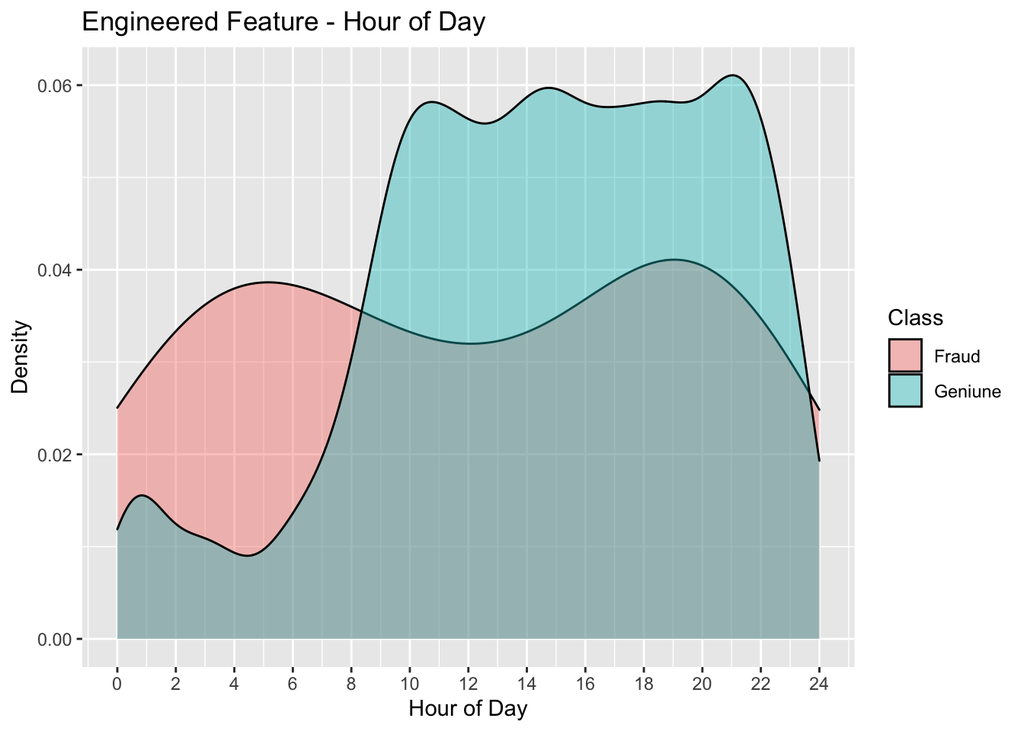

When comparing the hour money transacted, the density of geniune highly tends to be transacted on from 8am to 24pm, however, fraud event can be happen on 2am.

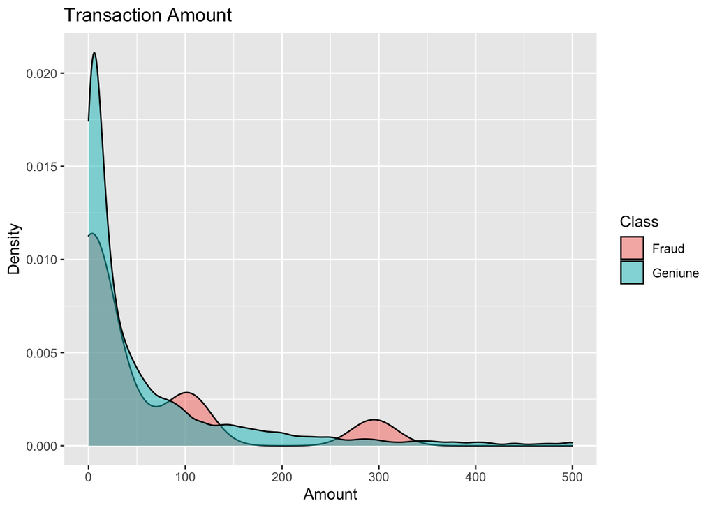

It shows that larger amount oftransactions are little bit more likely to be fraudulent. It’s not completely clear from the density graph below due to the restricted x range, but the right tail of the fraud density curve is larger, so a higher proportion of fraudulent transactions take a very large value.

### 4. Oversampling

```
## [1] "Proportion of sub train"
```

```
##
##   fraud genuine
##      12    7988
```

```
## [1] "Proportion of sub test"
```

```
##
##   fraud genuine
##       3    1997
```

```
## [1] "Proportion of full test"
```

```
##
##   fraud genuine
##      98   56863
```

```
## [1] "Proportion of sub train after SMOTE"
```

```
##
##   fraud genuine
##    1212    1200
```

As you see, the most big problem of this data is imbalance of “Class” variable. To overcome this I used SMOTE method to oversampling the fraud data.

Briefly, SMOTE first takes a sample of the data on the side with the least # of classifications and then looks for the k nearest neighbor of this sample. And find the difference between the current sample and these k neighbors annd multiply this difference by any value between 0 and 1 to add it to the original value. As a result, SMOTE operates by adding some points that have been moved in consideration of the neighbors around it.

### Data

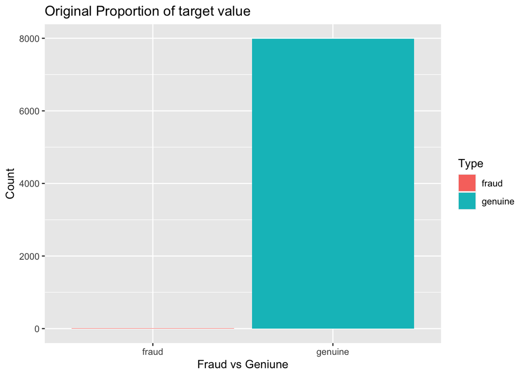

```
##
##   fraud genuine
##      12    7988
```

```
##
##   fraud genuine
##  0.0015  0.9985
```

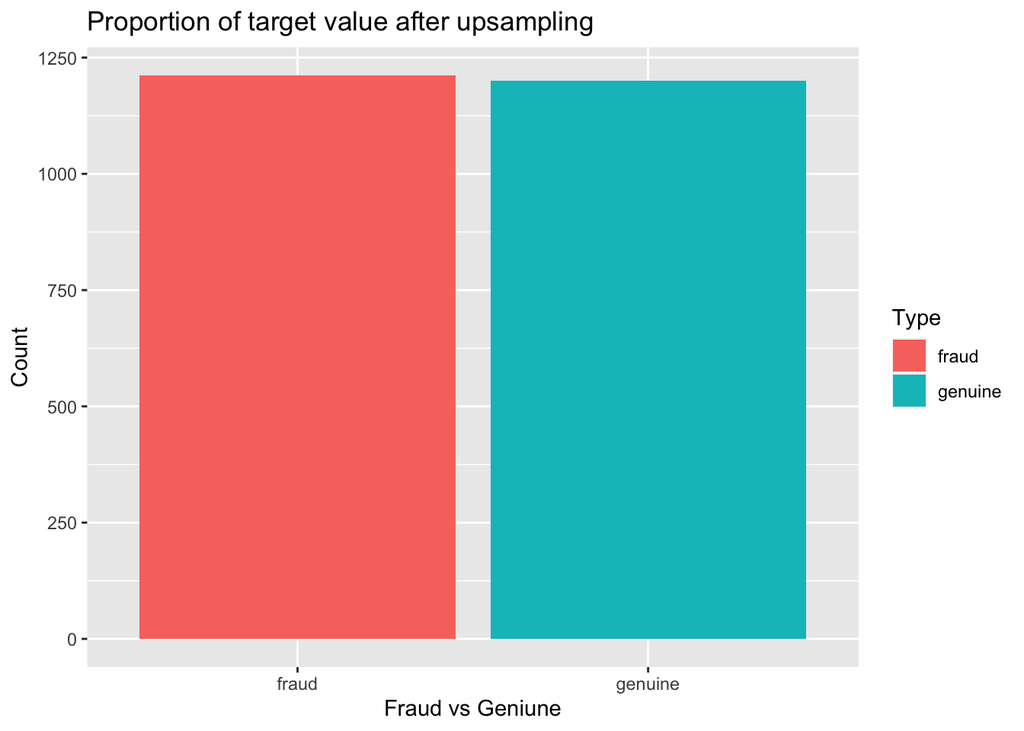

```
##
##   fraud genuine
##    1212    1200
```

```
##
##     fraud   genuine
## 0.5024876 0.4975124
```

After applying SMOTE, I have balanced proportion of target value for train data.

### Modeling

I’m going to test model performance on the original dataset which is imbalanced against altered dataset with SMOTE. Also, I used 5 fold cross validation method and “caret” package to train for choosing best parameter for each model.

I used “cc_tst” that are extracted from the full dataset, but used “cc_sub_trn” for training data. The reason is that if I use “cc_sub_tst” for evaluating model, the dataset contains a few “fraud” less than 20. To be specific, it was difficult to compare performance between models.

## Results

```
## [1] "rpart"
```

```
##          actual
## predicted fraud genuine
##   fraud      41       9
##   genuine    57   56854
```

```
##          actual
## predicted fraud genuine
##   fraud      79     208
##   genuine    19   56655
```

```
## [1] "nnet"
```

```
##          actual
## predicted fraud genuine
##   fraud      48      11
##   genuine    50   56852
```

```
##          actual
## predicted fraud genuine
##   fraud      70     300
##   genuine    28   56563
```

```
## [1] "gbm"
```

```
##          actual
## predicted fraud genuine
##   fraud      79     189
##   genuine    19   56674
```

```
##          actual
## predicted fraud genuine
##   fraud      79     208
##   genuine    19   56655
```

```
## [1] "rf"
```

```
##          actual
## predicted fraud genuine
##   fraud      54       7
##   genuine    44   56856
```

```
##          actual
## predicted fraud genuine
##   fraud      83      23
##   genuine    15   56840
```

[figure not shown]

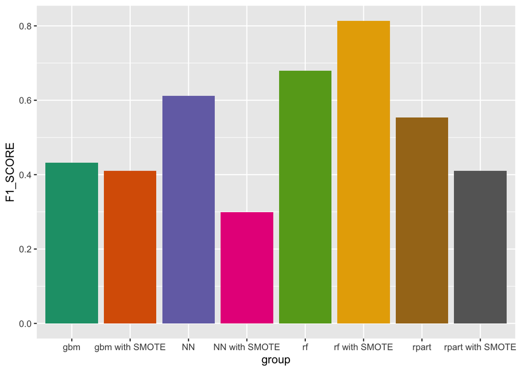

## Discussion

The SMOTE method can give more options of train data. In this project, I used only one condition of SMOTE, but if we generate multiple conditions, we could make a better model even with the higly imbalanced dataset. But I was pretty suprised that “F1 Scroe” of some model has decreased with balanced dataset. I think the reason is that rapid growth of “Sensitivity” causes decrease in “F1 Score”.

## Appendix

The feature descriptions are as follows:

Time - the seconds elapsed between each transaction and the first transaction in the dataset V1, V2, …, V28 - principal components obtained through dimensionality reduction (PCA) Amount - the transaction amount Class - the response variable, indicating whether a transaction was fraudulent or not